# Reporters Without Boarders Data Analysis

Homework for Nov 16.

The two main test I was considering doing was:

1. Confidence Interval/Margin of error (Setting a margin of error/confidence interval can help me know how far off my averages might be.)
2. A T-test via random sampling. (I can see if I take a random sample of 10 countries from the Americas and random sample of 10 countries from elsewhere and run a t-test the percentage change of countries from the Americas will always be lower.)

In my final project, I will be looking at Reporters Without Boarder’s World Freedom Index. The international nonprofit’s mission is to defend the freedom of information by protecting journalists worldwide.

Every year, RSF publishes their World Press Freedom Index, a chart that tracks 180 countries’ state of journalism. They look at factors including:

1. If journalists can make a livable wage (Economic factor)
2. If journalists are viewed as helpers of society (Social factor)
3. If journalists are supported by their governments (Political factor)
4. If journalists are safe reporting in their country (Safety factor)
5. If laws support the work of journalists (Legal factor)

All of these factors are added together to give a country an overall grade, scoring a country’s state of journalism. These scores change from year to year as a country’s state of journalism improves or worsens.

In my final project, I will see if countries in the Americas experienced larger drops in overall scores from 2025 - 2026 compared to the rest of the world.

My first step is to install my libraries, upload the data and clean it.

```r
library(tidyverse)
library(janitor)
```

```r
freedom_index_2026 <- read_csv("data/rsf_data_2026.csv")
freedom_index_2026 <- freedom_index_2026 |> clean_names()
```

This is the first set of rsf data from 2026. Let’s look at it.

```r
freedom_index_2026 |> tibble()
```

| country | iso | score_2026 | rank | political_context | rank_pol | economic_context | rank_eco | legal_context | rank_leg | social_context | rank_soc | safety | rank_saf | year_n | americas |
| --- | --- | --- | --- | --- | --- | --- | --- | --- | --- | --- | --- | --- | --- | --- | --- |
| Finland | FIN | 86.22 | 6 | 89.16 | 8 | 78.68 | 5 | 85.62 | 10 | 83.59 | 14 | 94.05 | 14 | 2026 | No |
| Estonia | EST | 88.54 | 3 | 90.29 | 4 | 75.33 | 8 | 89.25 | 5 | 92.33 | 1 | 95.53 | 7 | 2026 | No |
| Netherlands | NLD | 88.92 | 2 | 89.31 | 7 | 85.38 | 2 | 90.68 | 2 | 87.70 | 6 | 91.52 | 33 | 2026 | No |
| Sweden | SWE | 87.61 | 5 | 89.61 | 6 | 81.67 | 3 | 88.82 | 6 | 84.53 | 11 | 93.41 | 18 | 2026 | No |
| Lithuania | LTU | 81.34 | 15 | 74.05 | 24 | 68.03 | 14 | 86.29 | 8 | 85.82 | 9 | 92.49 | 26 | 2026 | No |
| Denmark | DNK | 88.47 | 4 | 91.79 | 2 | 79.51 | 4 | 86.56 | 7 | 88.79 | 5 | 95.69 | 5 | 2026 | No |
| Ireland | IRL | 85.93 | 7 | 90.50 | 3 | 76.59 | 6 | 80.82 | 25 | 86.20 | 7 | 95.54 | 6 | 2026 | No |
| Portugal | PRT | 83.71 | 10 | 86.76 | 9 | 62.25 | 26 | 85.86 | 9 | 89.29 | 4 | 94.40 | 12 | 2026 | No |
| Switzerland | CHE | 84.83 | 8 | 89.65 | 5 | 70.67 | 11 | 82.74 | 18 | 85.86 | 8 | 95.24 | 9 | 2026 | No |
| Czechia | CZE | 83.01 | 11 | 76.25 | 20 | 66.46 | 17 | 89.53 | 4 | 89.31 | 3 | 93.49 | 16 | 2026 | No |

[output cut: 170 more lines]

Great! Not only do we have each countries’ score, but we also have each countries’ ranking for each category.

Now, let’s see the data from last year.

```r
freedom_index_2025 <- read_csv("data/rsf_data_2025.csv")
freedom_index_2025 <- freedom_index_2025 |> clean_names()
```

Using this code, I can combine both of my data frames into a single data set. It will also give us the percentage changes from each country from 2025 - 2026. (Thanks, Derek!)

```r
score_changes <- freedom_index_2026 |>
  select(iso, country, score_2026, americas) |>
  inner_join(
    freedom_index_2025 |> select(iso, score_2025),
    by = "iso"
  ) |>
  mutate(
    pct_change = ((score_2026 - score_2025) / score_2025) * 100
  )
```

Now let’s see what the America look like

```r
score_changes |> filter(americas == "Yes")
```

| iso | country | score_2026 | americas | score_2025 | pct_change |
| --- | --- | --- | --- | --- | --- |
| TTO | Trinidad and Tobago | 74.70 | Yes | 79.71 | -6.28528416 |
| CAN | Canada | 78.76 | Yes | 78.75 | 0.01269841 |
| JAM | Jamaica | 75.87 | Yes | 75.83 | 0.05274957 |
| SUR | Suriname | 73.20 | Yes | 74.49 | -1.73177608 |
| CRI | Costa Rica | 72.35 | Yes | 73.09 | -1.01245040 |
| DOM | Dominican Republic | 69.73 | Yes | 69.87 | -0.20037212 |
| BLZ | Belize | 61.66 | Yes | 68.32 | -9.74824356 |
| CSS | OECS | 64.60 | Yes | 68.08 | -5.11163337 |
| PAN | Panama | 62.14 | Yes | 66.75 | -6.90636704 |
| USA | United States | 62.61 | Yes | 65.00 | -3.67692308 |

[output cut: 18 more lines]

Let’s find the average percentage point change and standard deviation of countries in the Americas.

```r
america_mean <- score_changes |> filter(americas == "Yes") |> summarize(mean = mean(pct_change), sd = sd(pct_change), median = median(pct_change))
```

Now, let’s look at every other country elsewhere.

```r
elsewhere_mean <- score_changes |> filter(americas == "No") |> summarize(mean = mean(pct_change), sd = sd(pct_change), median = median(pct_change))
```

Interesting! Countries in the Americas saw a larger drop in percentage points with an average of -1.13 than countries everywhere else. In fact, the countries elsewhere saw a positive percentage point increase by 0.25.

Now, let graph our findings using a boxplot.

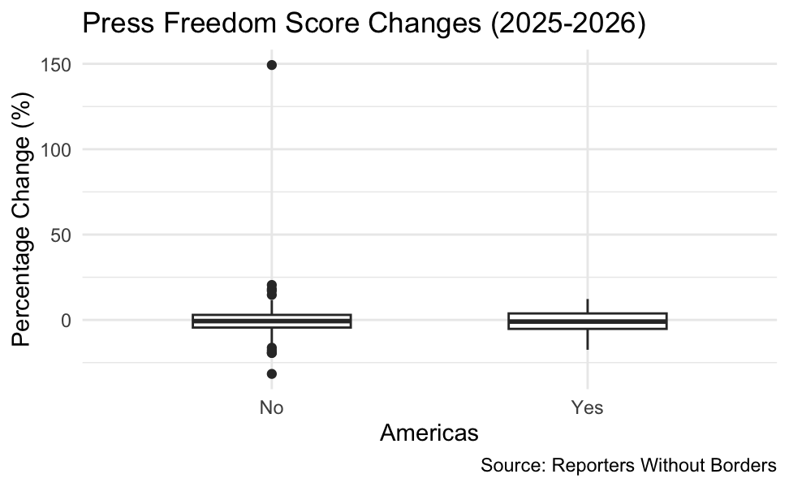

```r
ggplot(score_changes, aes(x = americas, y = pct_change)) +
  geom_boxplot(width = 0.5) +
  theme_minimal() +
  labs(title = "Press Freedom Score Changes (2025-2026)",
       x = "Americas",
       y = "Percentage Change (%)",
       caption = "Source: Reporters Without Borders")
```

# (Ask Derek about how to adjust the size an with of your box plots)!!

Now, let’s try a t-test to see if our findings our statsically significant.

**Null Hypothesis (H₀):** The average score is the same in both groups.

**Alternative Hypothesis (H₁):** The average score is not the same in both groups.

(I used AI to help me with this part. I was confused if I needed to split the two groups that were in a single data frame. AI told me that I needed to make another data frame that mutate the first to give me the categories I need to make the t-test possible.)

```r
score_changes_grouped <- score_changes |>
  mutate(
    region_group = if_else(americas == "Yes", "Americas", "Rest of World")
  )

t.test(pct_change ~ region_group, data = score_changes_grouped)
```

```
    Welch Two Sample t-test

data:  pct_change by region_group
t = -0.83018, df = 83.181, p-value = 0.4088
alternative hypothesis: true difference in means between group Americas and group Rest of World is not equal to 0
95 percent confidence interval:
 -4.736411  1.946796
sample estimates:
     mean in group Americas mean in group Rest of World
                 -1.1357508                   0.2590568
```

With a p-value of 0.408, the drop is not statically significant. We cannot drop the null. Though, the drop is still there.